# Detection of Novel Bio-markers Associated with Head and Neck Cancer in Myeloid Cells

Daphne Babirye

2023-08-08

##### 1.0 Loading Data

**1.1 Extract the Samples**

```r
#Get the working directory
getwd()
```

```
## [1] "G:/.shortcut-targets-by-id/1mriGKSWqFhyhY5W8IaX9SpRADck8_Gva/myeinfobank/R/Daphne.Babirye"
```

```r
#The working directory id the myeinfobank folder

#get all file names in folder
filenames<-list.files("Data/GSE139324_RAW")


#get the GSM numbers
gsm_numbers <- gsub("_(?!.*_).*", "", filenames, perl=TRUE)

# print unique GSM numbers
GSMs <- unique(gsm_numbers)
GSMs <-GSMs[-1]

#Select a few GSMs
#myGSMs<- GSMs[45:57]
myGSMs<- GSMs
myGSMs
```

```
##  [1] "GSM4138110_HNSCC_1_PBMC"  "GSM4138111_HNSCC_1_TIL"
##  [3] "GSM4138112_HNSCC_2_PBMC"  "GSM4138113_HNSCC_2_TIL"
##  [5] "GSM4138114_HNSCC_3_PBMC"  "GSM4138115_HNSCC_3_TIL"
##  [7] "GSM4138116_HNSCC_4_PBMC"  "GSM4138117_HNSCC_4_TIL"
##  [9] "GSM4138118_HNSCC_5_PBMC"  "GSM4138119_HNSCC_5_TIL"
## [11] "GSM4138120_HNSCC_6_PBMC"  "GSM4138121_HNSCC_6_TIL"
## [13] "GSM4138122_HNSCC_7_PBMC"  "GSM4138123_HNSCC_7_TIL"
## [15] "GSM4138124_HNSCC_8_PBMC"  "GSM4138125_HNSCC_8_TIL"
## [17] "GSM4138126_HNSCC_9_PBMC"  "GSM4138127_HNSCC_9_TIL"
## [19] "GSM4138128_HNSCC_10_PBMC" "GSM4138129_HNSCC_10_TIL"
## [21] "GSM4138130_HNSCC_11_PBMC" "GSM4138131_HNSCC_11_TIL"
## [23] "GSM4138132_HNSCC_12_PBMC" "GSM4138133_HNSCC_12_TIL"
## [25] "GSM4138134_HNSCC_13_PBMC" "GSM4138135_HNSCC_13_TIL"
## [27] "GSM4138136_HNSCC_14_PBMC" "GSM4138137_HNSCC_14_TIL"
## [29] "GSM4138138_HNSCC_15_PBMC" "GSM4138139_HNSCC_15_TIL"
```

[output cut: 17 more lines]

**1.2.Create the sce objects for the samples**

```r
# Define the directory
tempDir <- "temp_10x"

# Create the directory if it doesn't exist
if (!dir.exists(tempDir)) {
  dir.create(tempDir)
}

# Loop through GSMs
for (i in 1:length(myGSMs)) {

   # Select the filenames that contain the current GSM number (myGSMs[i]) and store them in names
   names <- filenames[grep(myGSMs[i], filenames)]

   # Copy each file to the directory and rename it
   file.copy(from = paste("Data/GSE139324_RAW/", names[1], sep=""),
             to = paste(tempDir, "/barcodes.tsv.gz", sep=""))
   file.copy(from = paste("Data/GSE139324_RAW/", names[2], sep=""),
             to = paste(tempDir, "/genes.tsv.gz", sep=""))
   file.copy(from = paste("Data/GSE139324_RAW/", names[3], sep=""),
             to = paste(tempDir, "/matrix.mtx.gz", sep=""))

   # Use the directory in the read10xCounts function
   sce <- read10xCounts(tempDir, col.names=TRUE, sample.names = myGSMs[i])

   # Create a new variable with the name "sce" followed by the current GSM number
   assign(paste("sce", myGSMs[i], sep=""), sce)

   # Remove the files from the directory for the next operation
   unlink(paste(tempDir, "/barcodes.tsv.gz", sep=""))
   unlink(paste(tempDir, "/genes.tsv.gz", sep=""))
   unlink(paste(tempDir, "/matrix.mtx.gz", sep=""))
}

# save one Rdata for all sce objects
save(list=ls()[grep("sceGSM",ls())],file="Data/sceGSMs.RData")

# Load the save R.data object
#load('Data/sceGSMs.RData')
```

**1.3. Merge the sce objects into one**

```r
#Merge the sce objects

#create a list of all sce objects
sce.list <- lapply(ls(pattern = "sceGSM"), get)

#Create one sce object by merging all the samples

#combine sce objects by column
sce.all <- do.call(cbind, sce.list)
sce.all
```

```
## class: SingleCellExperiment
## dim: 33694 133308
## metadata(63): Samples Samples ... Samples Samples
## assays(1): counts
## rownames(33694): ENSG00000243485 ENSG00000237613 ... ENSG00000277475
##   ENSG00000268674
## rowData names(2): ID Symbol
## colnames(133308): AAACCTGAGGAGCGTT-1 AAACCTGCACGGACAA-1 ...
##   TTTGTCATCACCCTCA-1 TTTGTCATCATGTAGC-1
## colData names(2): Sample Barcode
## reducedDimNames(0):
## mainExpName: NULL
## altExpNames(0):
```

Assigning Conditions of the cells (healthy or diseased) to ColData

```r
# Determine the condition based on 'Sample' column values
sce.all$condition <- ifelse(grepl("HNSCC", colData(sce.all)$Sample), "HNSCC",
                           ifelse(grepl("HD", colData(sce.all)$Sample), "HD", NA))


#Healthy cells
## Count the number of 'HD' conditions in colData
hd_count <- sum(colData(sce.all)$condition == 'HD')

# Print the count
cat("Number of cells with the 'HD' condition:", hd_count, "\n")
```

```
## Number of cells with the 'HD' condition: 25142
```

```r
#HNSCC cells

## Count the number of 'HD' conditions in colData
HNSCC_count <- sum(colData(sce.all)$condition == 'HNSCC')

# Print the count
cat("Number of cells with the 'HNSCC' condition:", HNSCC_count, "\n")
```

```
## Number of cells with the 'HNSCC' condition: 108166
```

##### 2.0. Exploratory Data Analysis

Explore the sce object

```r
# Check the dimensions and structure of the count matrix
print(dim(counts(sce.all)))
```

```
## [1]  33694 133308
```

```r
str(counts(sce.all))
```

```
## Formal class 'dgCMatrix' [package "Matrix"] with 6 slots
##   ..@ i       : int [1:172510380] 33 86 97 153 183 257 316 350 457 484 ...
##   ..@ p       : int [1:133309] 0 550 1620 2639 3631 5913 6379 7131 8229 8850 ...
##   ..@ Dim     : int [1:2] 33694 133308
##   ..@ Dimnames:List of 2
##   .. ..$ : chr [1:33694] "ENSG00000243485" "ENSG00000237613" "ENSG00000186092" "ENSG00000238009" ...
##   .. ..$ : chr [1:133308] "AAACCTGAGGAGCGTT-1" "AAACCTGCACGGACAA-1" "AAACCTGCAGAAGCAC-1" "AAACCTGCAGATGAGC-1" ...
##   ..@ x       : num [1:172510380] 1 1 1 2 1 1 1 1 1 2 ...
##   ..@ factors : list()
```

```r
#checking gene name format
# Fetch gene names
gene_names <- rownames(sce.all)

# Look at the first few gene names
head(gene_names)
```

```
## [1] "ENSG00000243485" "ENSG00000237613" "ENSG00000186092" "ENSG00000238009"
## [5] "ENSG00000239945" "ENSG00000239906"
```

```r
#Source: https://statomics.github.io/SGA/sequencing_singleCell.html


# Display the first 6 rows and 6 columns of the gene expression counts in sce.pbmc
sce.all %>%
  counts %>%
  head(n = c(6, 6))
```

```
## 6 x 6 sparse Matrix of class "dgCMatrix"
##                 AAACCTGAGGAGCGTT-1 AAACCTGCACGGACAA-1 AAACCTGCAGAAGCAC-1
## ENSG00000243485                  .                  .                  .
## ENSG00000237613                  .                  .                  .
## ENSG00000186092                  .                  .                  .
## ENSG00000238009                  .                  .                  .
## ENSG00000239945                  .                  .                  .
## ENSG00000239906                  .                  .                  .
##                 AAACCTGCAGATGAGC-1 AAACCTGGTCTCCCTA-1 AAACGGGAGATGCCAG-1
## ENSG00000243485                  .                  .                  .
## ENSG00000237613                  .                  .                  .
## ENSG00000186092                  .                  .                  .
## ENSG00000238009                  .                  .                  .
## ENSG00000239945                  .                  .                  .
## ENSG00000239906                  .                  .                  .
```

```r
# Check the class of the gene expression counts in sce.pbmc
sce.all %>%
  counts %>%
  class
```

```
## [1] "dgCMatrix"
## attr(,"package")
## [1] "Matrix"
```

```r
# Retrieve the available assays in the sce.pbmc object
sce.all %>%
  assays
```

```
## List of length 1
## names(1): counts
```

```r
# Display the first few rows of the row metadata in sce.pbmc
sce.all %>%
  rowData %>%
  head
```

```
## DataFrame with 6 rows and 2 columns
##                              ID        Symbol
##                     <character>   <character>
## ENSG00000243485 ENSG00000243485  RP11-34P13.3
## ENSG00000237613 ENSG00000237613       FAM138A
## ENSG00000186092 ENSG00000186092         OR4F5
## ENSG00000238009 ENSG00000238009  RP11-34P13.7
## ENSG00000239945 ENSG00000239945  RP11-34P13.8
## ENSG00000239906 ENSG00000239906 RP11-34P13.14
```

```r
# Display the first few rows of the column metadata in sce.pbmc
sce.all %>%
  colData %>%
  head
```

```
## DataFrame with 6 rows and 3 columns
##                                    Sample            Barcode   condition
##                               <character>        <character> <character>
## AAACCTGAGGAGCGTT-1 GSM4138110_HNSCC_1_P.. AAACCTGAGGAGCGTT-1       HNSCC
## AAACCTGCACGGACAA-1 GSM4138110_HNSCC_1_P.. AAACCTGCACGGACAA-1       HNSCC
## AAACCTGCAGAAGCAC-1 GSM4138110_HNSCC_1_P.. AAACCTGCAGAAGCAC-1       HNSCC
## AAACCTGCAGATGAGC-1 GSM4138110_HNSCC_1_P.. AAACCTGCAGATGAGC-1       HNSCC
## AAACCTGGTCTCCCTA-1 GSM4138110_HNSCC_1_P.. AAACCTGGTCTCCCTA-1       HNSCC
## AAACGGGAGATGCCAG-1 GSM4138110_HNSCC_1_P.. AAACGGGAGATGCCAG-1       HNSCC
```

```r
# Ensure the row names (which correspond to gene names) in the SingleCellExperiment (sce.pbmc) object are unique.
rownames(sce.all) <- uniquifyFeatureNames(rowData(sce.all)$ID, rowData(sce.all)$Symbol)

#store the unfiltered sce object in another variable
unfiltered <- sce.all
```

##### 3.0. Identifying Low Quality Cells

**3.1 Computing QC Metrics**

```r
# Identifying the location of genes
head(rownames(sce.all))
```

```
## [1] "RP11-34P13.3"  "FAM138A"       "OR4F5"         "RP11-34P13.7"
## [5] "RP11-34P13.8"  "RP11-34P13.14"
```

```r
is.mito<-grep("MT-",rownames(sce.all))

summary(is.mito)
```

```
##    Min. 1st Qu.  Median    Mean 3rd Qu.    Max.
##   12135   33655   33659   32122   33662   33665
```

```r
#compute the per-cell QC statistics of the SingleCellExperiment object
qc_metrics <- perCellQCMetrics(sce.all, subsets=list(Mito=is.mito))


# Summary statistics for qc metrics

# total sum of counts across all relevant features for each cell
summary(qc_metrics$sum)
```

```
##    Min. 1st Qu.  Median    Mean 3rd Qu.    Max.
##     488    2564    3590    4552    5092   91832
```

```r
#expressed features/genes in each cell
summary(qc_metrics$detected)
```

```
##    Min. 1st Qu.  Median    Mean 3rd Qu.    Max.
##      27     939    1151    1294    1448    7475
```

```r
#proportion of reads mapped to genes in the mitochondrial genome
summary(qc_metrics$subsets_Mito_percent)
```

```
##    Min. 1st Qu.  Median    Mean 3rd Qu.    Max.
##   0.000   2.094   2.980   3.433   4.147  98.851
```

```r
#percentage of reads mapped to ERCC transcripts
summary(qc_metrics$altexps_ERCC_percent)
```

```
## Length  Class   Mode
##      0   NULL   NULL
```

```r
# no reads mapped to ERCC transcripts
```

**3.2 Identifying Low Quality Cells**

Adaptive Thresholds (we can tell the reasons why a cell is an outlier) #identify cells that are outliers for the various QC metrics, based on the median absolute deviation (MAD) from the median value of each metric across all cells

```r
# Calculating per-cell QC filters for specific sub-fields of the dataframe

# Specifying the sub-fields of interest for per-cell QC filtering
sub.fields <- c("subsets_Mito_percent")

#Compute outliers for each sample separately

batch.reasons <- perCellQCFilters(qc_metrics, batch=sce.all$Sample,
                                  sub.fields=sub.fields)
colSums(as.matrix(batch.reasons))
```

```
##              low_lib_size            low_n_features high_subsets_Mito_percent
##                      1642                      2225                      5017
##                   discard
##                      6678
```

```r
# extracting the exact filter thresholds to check whether the selected thresholds are appropriate
#low_lib_size

print('low lib_size Thresholds')
```

```
## [1] "low lib_size Thresholds"
```

```r
attr(batch.reasons$low_lib_size, "thresholds")
```

```
##        GSM4138110_HNSCC_1_PBMC GSM4138111_HNSCC_1_TIL GSM4138112_HNSCC_2_PBMC
## lower                 966.5659               1624.465                1432.977
## higher                     Inf                    Inf                     Inf
##        GSM4138113_HNSCC_2_TIL GSM4138114_HNSCC_3_PBMC GSM4138115_HNSCC_3_TIL
## lower                1317.879                1634.849                1081.19
## higher                    Inf                     Inf                    Inf
##        GSM4138116_HNSCC_4_PBMC GSM4138117_HNSCC_4_TIL GSM4138118_HNSCC_5_PBMC
## lower                 1350.784               884.0411                2304.272
## higher                     Inf                    Inf                     Inf
##        GSM4138119_HNSCC_5_TIL GSM4138120_HNSCC_6_PBMC GSM4138121_HNSCC_6_TIL
## lower                987.5409                1995.345               1454.562
## higher                    Inf                     Inf                    Inf
##        GSM4138122_HNSCC_7_PBMC GSM4138123_HNSCC_7_TIL GSM4138124_HNSCC_8_PBMC
## lower                 1307.066               691.6916                 1296.47
## higher                     Inf                    Inf                     Inf
##        GSM4138125_HNSCC_8_TIL GSM4138126_HNSCC_9_PBMC GSM4138127_HNSCC_9_TIL
## lower                255.3396                779.4112               616.8363
## higher                    Inf                     Inf                    Inf
##        GSM4138128_HNSCC_10_PBMC GSM4138129_HNSCC_10_TIL
## lower                  1053.109                661.2098
## higher                      Inf                     Inf
##        GSM4138130_HNSCC_11_PBMC GSM4138131_HNSCC_11_TIL
## lower                  775.8806                520.2865
## higher                      Inf                     Inf
##        GSM4138132_HNSCC_12_PBMC GSM4138133_HNSCC_12_TIL
## lower                  589.9064                533.3911
## higher                      Inf                     Inf
##        GSM4138134_HNSCC_13_PBMC GSM4138135_HNSCC_13_TIL
## lower                  334.9934                518.0379
## higher                      Inf                     Inf
##        GSM4138136_HNSCC_14_PBMC GSM4138137_HNSCC_14_TIL
## lower                  741.0938                 476.858
## higher                      Inf                     Inf
##        GSM4138138_HNSCC_15_PBMC GSM4138139_HNSCC_15_TIL
## lower                  543.3041                  514.66
## higher                      Inf                     Inf
##        GSM4138140_HNSCC_16_PBMC GSM4138141_HNSCC_16_TIL
## lower                   930.786                 867.298
## higher                      Inf                     Inf
##        GSM4138142_HNSCC_17_PBMC GSM4138143_HNSCC_17_TIL
```

[output cut: 26 more lines]

```
##        GSM4138160_HNSCC_26_PBMC GSM4138161_HNSCC_26_TIL GSM4138162_HD_1_PBMC
## lower                  1426.693                1070.813             1400.356
## higher                      Inf                     Inf                  Inf
##        GSM4138163_HD_2_PBMC GSM4138164_HD_3_PBMC GSM4138165_HD_4_PBMC
## lower              1330.542             2138.526              1763.32
## higher                  Inf                  Inf                  Inf
##        GSM4138166_HD_5_PBMC GSM4138167_HD_6_PBMC GSM4138168_HD_1_Tonsil
## lower              819.0962             1031.877               1877.778
## higher                  Inf                  Inf                    Inf
##        GSM4138169_HD_2_Tonsil GSM4138170_HD_3_Tonsil GSM4138171_HD_4_Tonsil
## lower                1845.361               1006.962               1133.054
## higher                    Inf                    Inf                    Inf
##        GSM4138172_HD_5_Tonsil
## lower                973.1468
## higher                    Inf
```

```r
#low_n_features
print('Low n_features Thresholds')
```

```
## [1] "Low n_features Thresholds"
```

```r
attr(batch.reasons$low_n_features, "thresholds")
```

```
##        GSM4138110_HNSCC_1_PBMC GSM4138111_HNSCC_1_TIL GSM4138112_HNSCC_2_PBMC
## lower                 521.4266               405.3441                631.6873
## higher                     Inf                    Inf                     Inf
##        GSM4138113_HNSCC_2_TIL GSM4138114_HNSCC_3_PBMC GSM4138115_HNSCC_3_TIL
## lower                683.1873                 735.579               569.1881
## higher                    Inf                     Inf                    Inf
##        GSM4138116_HNSCC_4_PBMC GSM4138117_HNSCC_4_TIL GSM4138118_HNSCC_5_PBMC
## lower                 680.5276               447.7461                 814.767
## higher                     Inf                    Inf                     Inf
##        GSM4138119_HNSCC_5_TIL GSM4138120_HNSCC_6_PBMC GSM4138121_HNSCC_6_TIL
## lower                521.3176                587.7875               554.1753
## higher                    Inf                     Inf                    Inf
##        GSM4138122_HNSCC_7_PBMC GSM4138123_HNSCC_7_TIL GSM4138124_HNSCC_8_PBMC
## lower                 662.4188               394.5171                585.1854
## higher                     Inf                    Inf                     Inf
##        GSM4138125_HNSCC_8_TIL GSM4138126_HNSCC_9_PBMC GSM4138127_HNSCC_9_TIL
## lower                152.2119                461.7454               352.9947
## higher                    Inf                     Inf                    Inf
##        GSM4138128_HNSCC_10_PBMC GSM4138129_HNSCC_10_TIL
## lower                  434.5937                 382.252
## higher                      Inf                     Inf
##        GSM4138130_HNSCC_11_PBMC GSM4138131_HNSCC_11_TIL
## lower                  452.8929                 347.746
## higher                      Inf                     Inf
##        GSM4138132_HNSCC_12_PBMC GSM4138133_HNSCC_12_TIL
## lower                  378.5173                307.5304
## higher                      Inf                     Inf
##        GSM4138134_HNSCC_13_PBMC GSM4138135_HNSCC_13_TIL
## lower                  284.5632                314.1338
## higher                      Inf                     Inf
##        GSM4138136_HNSCC_14_PBMC GSM4138137_HNSCC_14_TIL
## lower                  424.1281                305.6689
## higher                      Inf                     Inf
##        GSM4138138_HNSCC_15_PBMC GSM4138139_HNSCC_15_TIL
## lower                  368.0676                305.6436
## higher                      Inf                     Inf
##        GSM4138140_HNSCC_16_PBMC GSM4138141_HNSCC_16_TIL
## lower                  472.5308                416.5604
## higher                      Inf                     Inf
##        GSM4138142_HNSCC_17_PBMC GSM4138143_HNSCC_17_TIL
```

[output cut: 26 more lines]

```
##        GSM4138160_HNSCC_26_PBMC GSM4138161_HNSCC_26_TIL GSM4138162_HD_1_PBMC
## lower                  624.5565                557.9446             606.0907
## higher                      Inf                     Inf                  Inf
##        GSM4138163_HD_2_PBMC GSM4138164_HD_3_PBMC GSM4138165_HD_4_PBMC
## lower              566.0384             806.3496             682.7426
## higher                  Inf                  Inf                  Inf
##        GSM4138166_HD_5_PBMC GSM4138167_HD_6_PBMC GSM4138168_HD_1_Tonsil
## lower              499.9429             540.5683               621.7796
## higher                  Inf                  Inf                    Inf
##        GSM4138169_HD_2_Tonsil GSM4138170_HD_3_Tonsil GSM4138171_HD_4_Tonsil
## lower                591.7288               451.4646                 452.61
## higher                    Inf                    Inf                    Inf
##        GSM4138172_HD_5_Tonsil
## lower                464.3478
## higher                    Inf
```

```r
#Source: http://bioconductor.org/books/3.17/OSCA.advanced/quality-control-redux.html#qc-batch
```

**3.3 Checking diagnostic plots** Inspect the distributions of QC metrics to identify possible problems

```r
# Attach QC metrics to the metadata of 'sce.all' dataset
colData(sce.all) <- cbind(colData(sce.all), qc_metrics)

# Create 'discard' variable and assign 'batch.reasons$discard' values
sce.all$discard <- batch.reasons$discard
colData(sce.all)
```

```
## DataFrame with 133308 rows and 10 columns
##                                    Sample            Barcode   condition
##                               <character>        <character> <character>
## AAACCTGAGGAGCGTT-1 GSM4138110_HNSCC_1_P.. AAACCTGAGGAGCGTT-1       HNSCC
## AAACCTGCACGGACAA-1 GSM4138110_HNSCC_1_P.. AAACCTGCACGGACAA-1       HNSCC
## AAACCTGCAGAAGCAC-1 GSM4138110_HNSCC_1_P.. AAACCTGCAGAAGCAC-1       HNSCC
## AAACCTGCAGATGAGC-1 GSM4138110_HNSCC_1_P.. AAACCTGCAGATGAGC-1       HNSCC
## AAACCTGGTCTCCCTA-1 GSM4138110_HNSCC_1_P.. AAACCTGGTCTCCCTA-1       HNSCC
## ...                                   ...                ...         ...
## TTTGTCAAGCTGCCCA-1 GSM4138172_HD_5_Tonsil TTTGTCAAGCTGCCCA-1          HD
## TTTGTCAAGGGAACGG-1 GSM4138172_HD_5_Tonsil TTTGTCAAGGGAACGG-1          HD
## TTTGTCACATGGGACA-1 GSM4138172_HD_5_Tonsil TTTGTCACATGGGACA-1          HD
## TTTGTCATCACCCTCA-1 GSM4138172_HD_5_Tonsil TTTGTCATCACCCTCA-1          HD
## TTTGTCATCATGTAGC-1 GSM4138172_HD_5_Tonsil TTTGTCATCATGTAGC-1          HD
##                          sum  detected subsets_Mito_sum subsets_Mito_detected
##                    <numeric> <integer>        <numeric>             <integer>
## AAACCTGAGGAGCGTT-1      1077       550              161                    11
## AAACCTGCACGGACAA-1      4296      1070              148                    11
## AAACCTGCAGAAGCAC-1      2903      1019              150                    10
## AAACCTGCAGATGAGC-1      2351       992              251                    11
## AAACCTGGTCTCCCTA-1     10368      2282              342                    10
## ...                      ...       ...              ...                   ...
## TTTGTCAAGCTGCCCA-1      1931       636              200                    11
## TTTGTCAAGGGAACGG-1      2682      1061               49                    11
## TTTGTCACATGGGACA-1      2235       707               48                     9
## TTTGTCATCACCCTCA-1      5262      1715              184                    11
## TTTGTCATCATGTAGC-1      2940       929              103                    10
##                    subsets_Mito_percent     total   discard
##                               <numeric> <numeric> <logical>
## AAACCTGAGGAGCGTT-1             14.94893      1077      TRUE
## AAACCTGCACGGACAA-1              3.44507      4296     FALSE
## AAACCTGCAGAAGCAC-1              5.16707      2903     FALSE
## AAACCTGCAGATGAGC-1             10.67631      2351      TRUE
## AAACCTGGTCTCCCTA-1              3.29861     10368     FALSE
## ...                                 ...       ...       ...
## TTTGTCAAGCTGCCCA-1             10.35733      1931      TRUE
## TTTGTCAAGGGAACGG-1              1.82699      2682     FALSE
## TTTGTCACATGGGACA-1              2.14765      2235     FALSE
## TTTGTCATCACCCTCA-1              3.49677      5262     FALSE
## TTTGTCATCATGTAGC-1              3.50340      2940     FALSE
```

plot QC metrics for first 8 samples

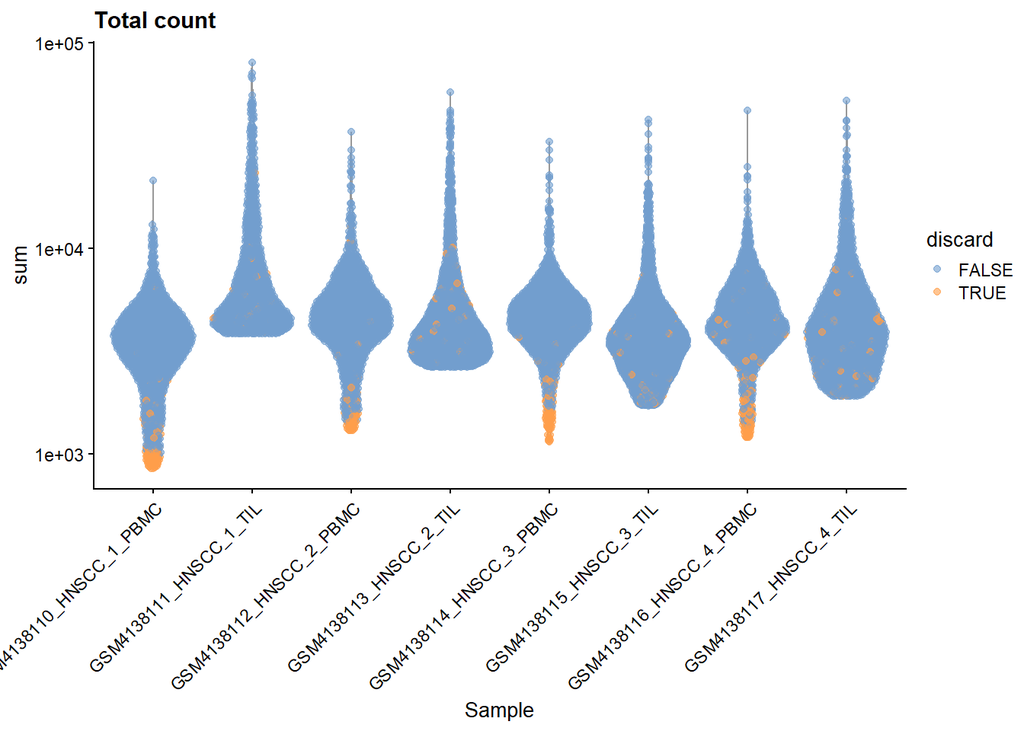

```r
# identify unique samples
unique_samples <- unique(colData(sce.all)$Sample)

# Get the cells that belong to the first 10 samples
cells_for_first_10_samples <- which(colData(sce.all)$Sample %in% unique_samples[1:8])

# Subset the sce.all object
sce.subset <- sce.all[, cells_for_first_10_samples]


# Generate a grid arrangement of diagnostic plots but only for the first 10 samples

plotColData(sce.subset, x='Sample', y="sum", colour_by="discard") +  # Plot total count of gene expression, colored by 'discard'
    scale_y_log10() + ggtitle("Total count")+  # Apply log10 scale to y-axis and set plot title
  theme(axis.text.x = element_text(angle = 45, hjust = 1))
```

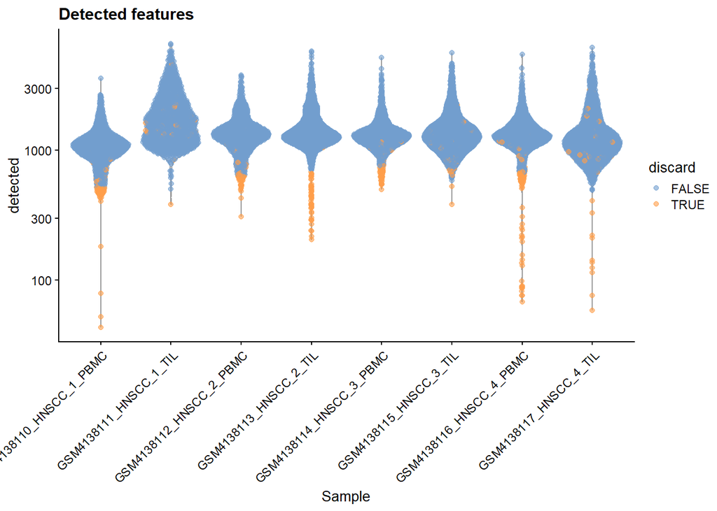

```r
plotColData(sce.subset, x='Sample', y="detected", colour_by="discard") +  # Plot number of detected features, colored by 'discard'
    scale_y_log10() + ggtitle("Detected features")+  # Apply log10 scale to y-axis and set plot title
  theme(axis.text.x = element_text(angle = 45, hjust = 1))
```

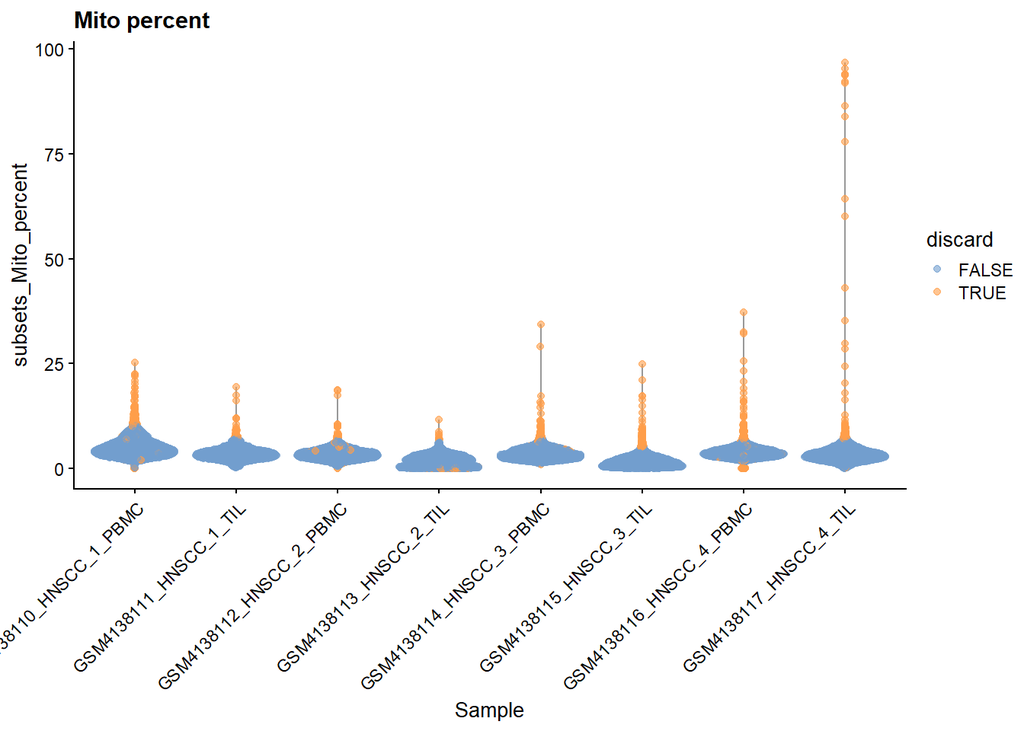

```r
plotColData(sce.subset, x='Sample', y="subsets_Mito_percent",  # Plot percentage of mitochondrial genes, colored by 'discard'
              colour_by="discard") + ggtitle("Mito percent")+  # Set plot title
  theme(axis.text.x = element_text(angle = 45, hjust = 1))
```

```r
   # ncol=1  # Arrange the plots in one column
```

Generate a diagnostic plot showing the relationship between total count and percentage of mitochondrial genes

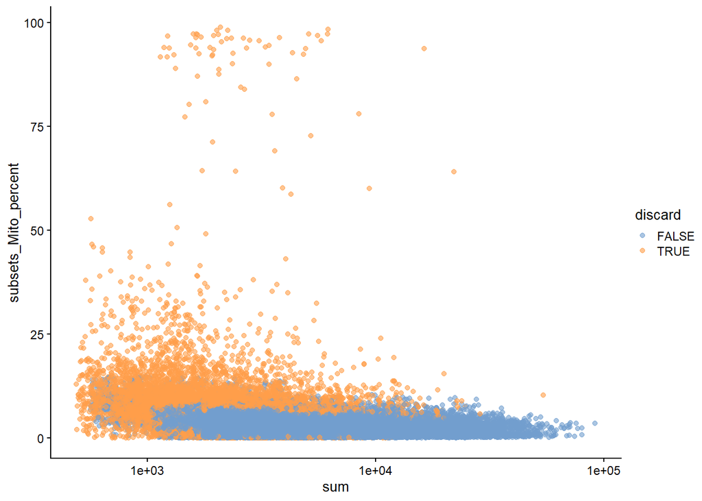

```r
plotColData(sce.all, x="sum", y="subsets_Mito_percent",
            colour_by="discard") + scale_x_log10()  # Apply log10 scale to x-axis
```

**3.4 Removing outliers**

```r
# Remove low quality cells and Keep the columns with good cells.
sce.all <- sce.all[,!batch.reasons$discard]

sce.all
```

```
## class: SingleCellExperiment
## dim: 33694 126630
## metadata(63): Samples Samples ... Samples Samples
## assays(1): counts
## rownames(33694): RP11-34P13.3 FAM138A ... AC213203.1 FAM231B
## rowData names(2): ID Symbol
## colnames(126630): AAACCTGCACGGACAA-1 AAACCTGCAGAAGCAC-1 ...
##   TTTGTCATCACCCTCA-1 TTTGTCATCATGTAGC-1
## colData names(10): Sample Barcode ... total discard
## reducedDimNames(0):
## mainExpName: NULL
## altExpNames(0):
```

##### 4.0. Normalisation

Using Scaling and log transformation

```r
# Set random number seed for reproducibility
set.seed(100)

# Perform quick clustering of cells
clust.sce.all <- scran::quickCluster(sce.all)
unique(clust.sce.all)
```

```
##  [1] 6  15 21 13 18 11 8  16 4  19 7  23 5  22 12 9  2  10 1  17 14 24 20 3
## Levels: 1 2 3 4 5 6 7 8 9 10 11 12 13 14 15 16 17 18 19 20 21 22 23 24
```

```r
# Compute size factors for normalization
sce.all <- scran::computeSumFactors(sce.all, cluster=clust.sce.all, min.mean=0.1)

# Perform logarithmic transformation of counts
sce.all <- logNormCounts(sce.all)

# Retrieve assay names
assayNames(sce.all)
```

```
## [1] "counts"    "logcounts"
```

```r
#generates a summary of the size factors calculated for each cell
summary(sizeFactors(sce.all))
```

```
##     Min.  1st Qu.   Median     Mean  3rd Qu.     Max.
##  0.07301  0.57514  0.75921  1.00000  1.06495 23.11686
```

Generate a scatter plot to visualize the relationship between library size factors and deconvolution factors

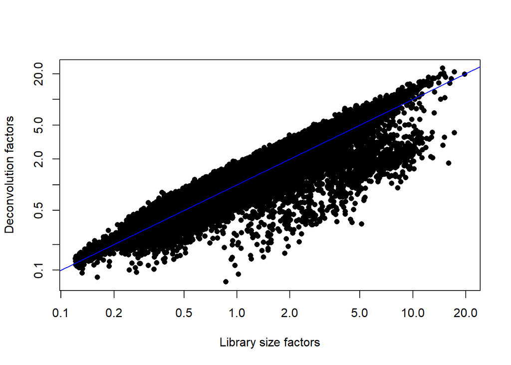

```r
#Relationship between the library size factors and the deconvolution size factors
plot(librarySizeFactors(sce.all), sizeFactors(sce.all), pch=16, xlab="Library size factors",
     ylab="Deconvolution factors", log="xy")

#add abline
abline(a=0, b=1, col="blue")
```

##### 5.0. Feature Selection

**5.1.Quantifying Technical Noise/Variance Modeling**

Create a trend by making some distributional assumptions about the noise.It is assumed that the noise exhibits near-Poisson variation as seen in UMI counts when only technical noise from library preparation and sequencing is considered.

```r
#set seed for reproducibility
set.seed(100)

# Model the gene-specific variance for each cell in the dataset using a Poisson distribution
dec.sce.all <- modelGeneVarByPoisson(sce.all, block = sce.all$Sample)

#Display the first rows of the gene-specific variance, sorted by the 'bio' column in descending order
head(dec.sce.all[order(dec.sce.all$bio, decreasing=TRUE),])
```

```
## DataFrame with 6 rows and 7 columns
##              mean     total      tech       bio   p.value       FDR
##         <numeric> <numeric> <numeric> <numeric> <numeric> <numeric>
## LYZ       1.37107   3.53155  0.550763   2.98079         0         0
## S100A9    1.40748   3.47965  0.512812   2.96684         0         0
## HLA-DRA   1.91550   3.39786  0.681227   2.71663         0         0
## CD74      2.69585   3.14373  0.512564   2.63117         0         0
## S100A8    1.25354   3.07271  0.522096   2.55061         0         0
## GNLY      1.06591   2.79460  0.586175   2.20843         0         0
##                                                                                            per.block
##                                                                                          <DataFrame>
## LYZ     2.30208:5.92940:0.733517:...:1.087825:2.84667:0.511789:...:1.506991:4.39552:0.712371:...:...
## S100A9  2.22009:5.31377:0.763464:...:0.785699:1.88503:0.451049:...:1.901994:5.77868:0.633077:...:...
## HLA-DRA 1.75732:3.36486:0.911471:...:2.350107:4.33211:0.349260:...:1.724470:3.36649:0.676534:...:...
## CD74    2.27119:2.57925:0.744852:...:3.263140:3.72918:0.195654:...:2.435216:3.29080:0.483107:...:...
## S100A8  1.98133:4.85772:0.846446:...:0.642935:1.47602:0.395564:...:1.902222:5.88040:0.633017:...:...
## GNLY    1.76979:4.33567:0.908385:...:0.922199:2.05106:0.488636:...:0.343612:1.12729:0.315084:...:...
```

Plot the variance of normalized log-expression values for each gene in the dataset, against the mean log-expression The blue line represents represents the mean-variance relationship corresponding to Poisson noise

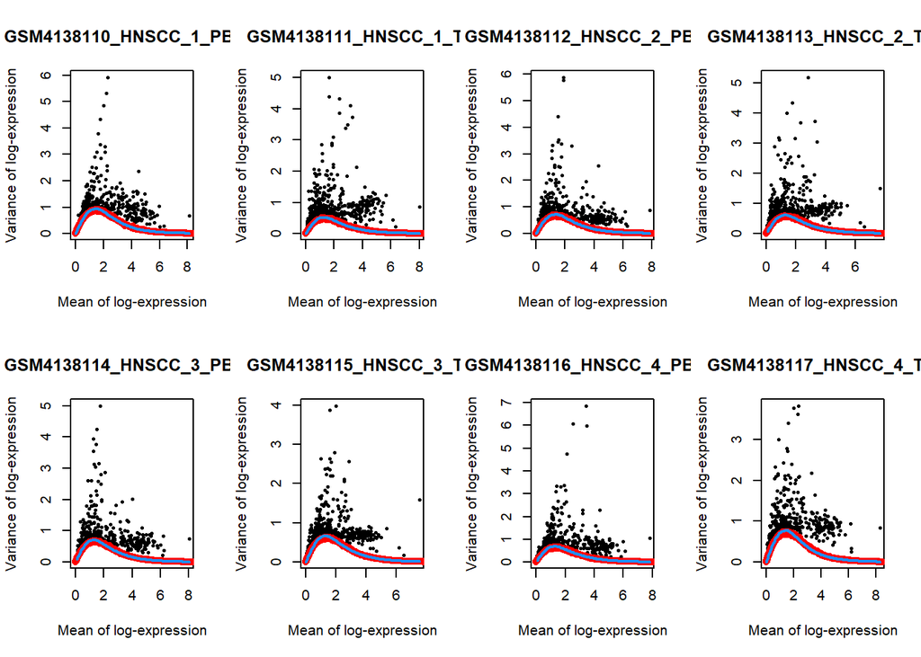

```r
# Per Sample Plots of Variance for 8 samples
par(mfrow=c(2,4))

blocked.stats <- dec.sce.all$per.block

# Only take the first 8 columns for plotting
sample_columns <- colnames(blocked.stats)[1:8]

for (i in sample_columns) {
  current <- blocked.stats[[i]]
  plot(current$mean, current$total, main=i, pch=16, cex=0.5,
       xlab="Mean of log-expression", ylab="Variance of log-expression")
  curfit <- metadata(current)
  points(curfit$mean, curfit$var, col="red", pch=16)
  curve(curfit$trend(x), col='dodgerblue', add=TRUE, lwd=2)
}
```

**5.2.Selecting Highly variable genes**

```r
#Selecting the top 10% highly variable genes
chosen <- getTopHVGs(dec.sce.all, prop=0.1)

# Displaying the structure of the chosen Highly Variable Genes (HVGs)
str(chosen)
```

```
##  chr [1:2241] "LYZ" "S100A9" "HLA-DRA" "CD74" "S100A8" "GNLY" "CCL5" "NKG7" ...
```

##### 6.0 Batch correction & Dimensional Reduction & 7.0 Dimensional Reduction

Remove the effects of batches/ different samples and undertakes PA

```r
set.seed(100)

sce.corrected <- correctExperiments(sce.all,
                                    batch = sce.all$Sample,
                                    restrict = NULL,
                                    subset.row = chosen,
                                    correct.all = TRUE,
                                    assay.type = "logcounts",
                                    PARAM = FastMnnParam(),
                                    combine.assays = NULL,
                                    combine.coldata = NULL,
                                    include.rowdata = TRUE,
                                    add.single = TRUE
                                    )

#assign the new object back to sce.all
sce.all <- sce.corrected

sce.all
```

```
## class: SingleCellExperiment
## dim: 33694 126630
## metadata(65): merge.info pca.info ... Samples Samples
## assays(3): reconstructed counts logcounts
## rownames(33694): RP11-34P13.3 FAM138A ... AC213203.1 FAM231B
## rowData names(3): rotation ID Symbol
## colnames(126630): AAACCTGCACGGACAA-1 AAACCTGCAGAAGCAC-1 ...
##   TTTGTCATCACCCTCA-1 TTTGTCATCATGTAGC-1
## colData names(12): batch Sample ... discard sizeFactor
## reducedDimNames(1): corrected
## mainExpName: NULL
## altExpNames(0):
```

```r
#Source: R documentation
```

UMAP was chosen because UMAP aims to preserve more global structure although this reduces resolution within each visual cluster. UMAP is also much faster than t-SNE

```r
# Set the random number seed to ensure reproducibility
set.seed(100)

# Run UMAP (Uniform Manifold Approximation and Projection) on the data 'sce.all'
# using the 'MNN' (Mutual Nearest Neighbors) dimensionality reduction.
# The 'external_neighbors' parameter set to TRUE allows the function to detect neighbors
# external to the UMAP space, thus improving the UMAP visualization.
# 'AnnoyParam()' is used as a parameter to speed up the neighbor searching process.
sce.all <- runUMAP(sce.all, dimred="corrected",
    external_neighbors=TRUE,
    BNPARAM=AnnoyParam())
```

##### 8.0.Clustering

```r
# Set the random number seed to ensure reproducibility
set.seed(100)

# Assign cluster labels to the cells in 'sce.all' based on their coordinates in the "MNN" reduced dimension space.
# This is achieved through a two-step clustering process.
# First step is k-means clustering with 1000 centers, followed by the construction of a k-nearest neighbors graph with 10 neighbors.
colLabels(sce.all) <- clusterRows(reducedDim(sce.all, "corrected"),
    TwoStepParam(KmeansParam(centers=1000), NNGraphParam(k=10)))
# Display the count of cells assigned to each cluster
table(colLabels(sce.all))
```

```
##
##     1     2     3     4     5     6     7     8     9    10    11
## 13610 20399 26448 15510  8022 13218  8281  5001  3099  1495 11547
```

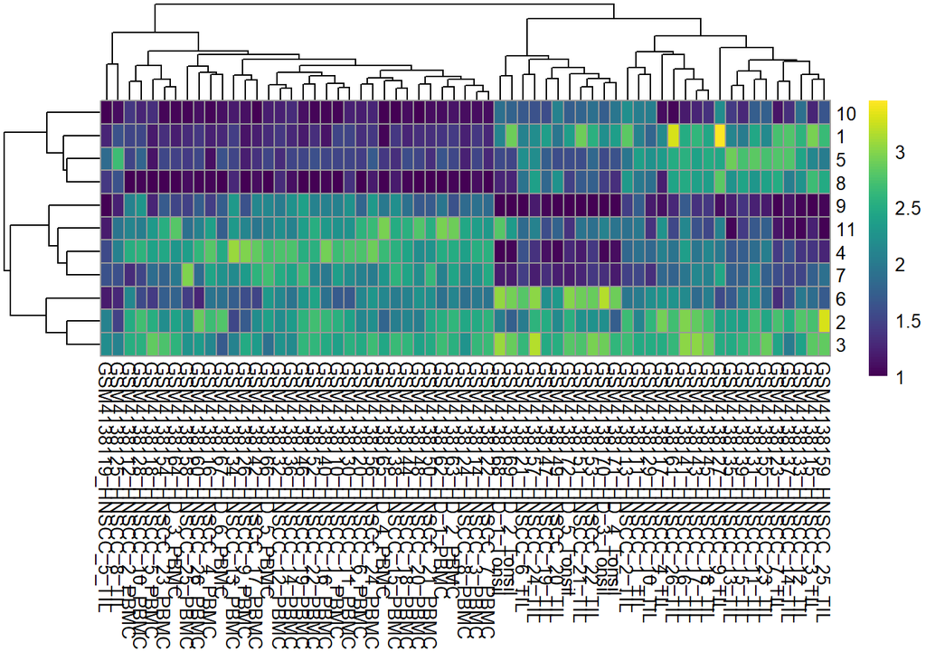

```r
# Construct a contingency table of cluster labels against sample batches
tab <- table(Cluster=colLabels(sce.all), batch = sce.all$Sample)

# Load the 'pheatmap' library for plotting
library(pheatmap)

# Generate a heatmap using the contingency table. Log transformation is applied to scale the color gradient and ensure clarity in visualization.
# The '+10' in log transformation is to avoid log(0) and adjust the color scale. 'viridis' color palette is used for the heatmap.
pheatmap(log10(tab+10), color=viridis::viridis(100))
```

```r
#Comparing these clusters to the batch labels using a heat map checks for any remaining batch effects post correction.
```

Visualise the clusters

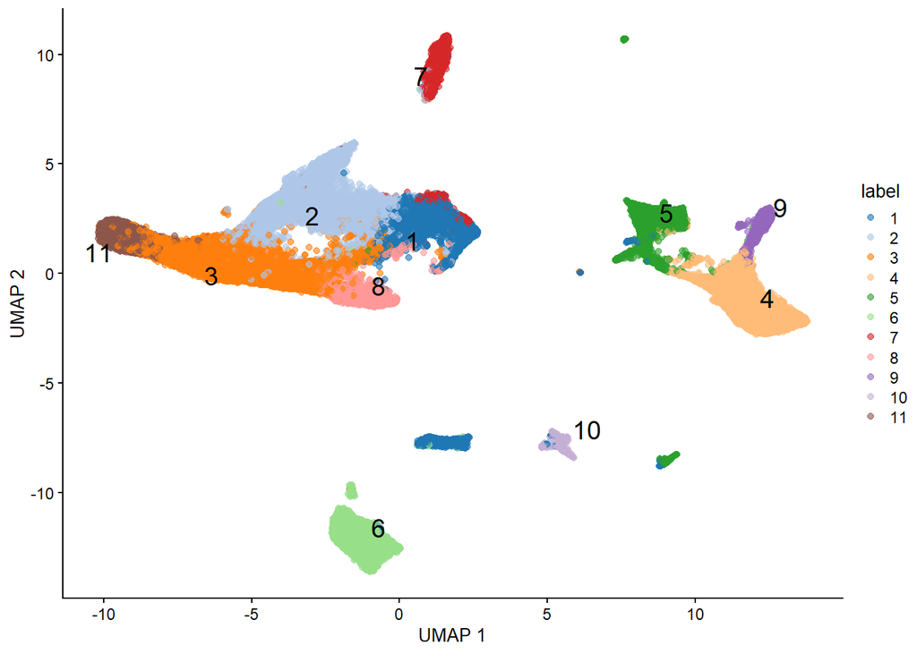

```r
# Plot the cells in a UMAP (Uniform Manifold Approximation and Projection) plot, with cells colored by their assigned cluster
# and the cluster number displayed on the plot. This visualization helps to see how cells of different clusters are related spatially.

# add scrambling option in scater's plotting functions.
scrambled <- sample(ncol(sce.all))

plotUMAP(sce.all, colour_by="label", text_by="label")
```

[figure not shown]

```r
plotUMAP(sce.all[,scrambled], colour_by="Sample")
```

```r
#plots of clusters for each sample of the dataset.
#Each point represents a cell that is colored by  batch.
#table(Cluster=colLabels(sce.all), Donor=sce.all$batch)
```

##### 9.0 Marker Gene Detection

```r
set.seed(100)
marker.info <- findMarkers(sce.all, block = sce.all$Sample, direction = 'up', lfc = 1)
marker.info
```

```
## List of length 11
## names(11): 1 2 3 4 5 6 7 8 9 10 11
```

**Top Marker genes for each cluster**

```r
#Create a function to detect the marker genes for each cluster
selectMarkerGenes <- function(marker.info) {
  # Initialize an empty list to store the marker genes for each cluster
  markersList <- list()

  # Loop through each cluster
  for(i in seq_along(marker.info)) {
    # Select the marker info for the current cluster
    cluster.markers <- marker.info[[i]]

    chosen.top.markers <- head(cluster.markers[cluster.markers$Top <= 10,],15)

    chosen.top.markers <- chosen.top.markers[,1:4]

    lfcs <- getMarkerEffects(chosen.top.markers)


    # Add the top marker genes to the list
    markersList[[paste0("markers_", i)]] <- chosen.top.markers

  }

  return(markersList)
}

# Run fuction to detect marker genes
markerGenes <- selectMarkerGenes(marker.info)
markerGenes
```

```
## $markers_1
## DataFrame with 15 rows and 4 columns
##               Top      p.value          FDR summary.logFC
##         <integer>    <numeric>    <numeric>     <numeric>
## CD74            1  0.00000e+00  0.00000e+00       1.81470
## ACTB            1 9.95458e-152 2.23606e-148       2.06162
## CD3D            1  0.00000e+00  0.00000e+00       1.81465
## GAPDH           1 5.24205e-203 1.35866e-199       1.43779
## GZMB            1  0.00000e+00  0.00000e+00       2.44219
## ...           ...          ...          ...           ...
## ALOX5AP         2 1.54686e-118 3.25749e-115      1.347562
## TRAC            2  0.00000e+00  0.00000e+00      1.823864
## ACTG1           2  1.52504e-25  2.14102e-22      1.405846
## HMGN1           2  4.00466e-15  4.81903e-12      0.866082
## ID2             3  7.44505e-54  1.32028e-50      1.146237
##
## $markers_2
## DataFrame with 15 rows and 4 columns
##              Top      p.value          FDR summary.logFC
##        <integer>    <numeric>    <numeric>     <numeric>
## GZMK           1            0            0       1.80599
## CD3D           1            0            0       1.99036
## CCL5           1            0            0       3.60421
## MALAT1         2            0            0       1.40580
## TRAC           2            0            0       1.79802
## ...          ...          ...          ...           ...
## CD52           4 2.31308e-136 2.78346e-133       1.43998
## CXCR4          4 9.21554e-193 1.19426e-189       1.47840
## S100A4         5  0.00000e+00  0.00000e+00       1.60460
## RPS27          5 6.89909e-124 7.74860e-121       1.13394
## RPLP2          5 2.58501e-126 3.00342e-123       1.37490
##
## $markers_3
## DataFrame with 15 rows and 4 columns
##              Top      p.value          FDR summary.logFC
##        <integer>    <numeric>    <numeric>     <numeric>
## S100A4         1 9.32058e-228  4.8315e-225       1.50996
## RPL34          1  0.00000e+00   0.0000e+00       1.56640
## LTB            1  0.00000e+00   0.0000e+00       2.87829
## RPLP2          1  0.00000e+00   0.0000e+00       1.68539
```

[output cut: 120 more lines]

```
## $markers_11
## DataFrame with 15 rows and 4 columns
##              Top   p.value       FDR summary.logFC
##        <integer> <numeric> <numeric>     <numeric>
## RPS27          1         0         0       2.16838
## RPL32          1         0         0       2.30197
## RPL34          1         0         0       2.29593
## RPS13          1         0         0       2.28775
## CD3D           1         0         0       2.09795
## ...          ...       ...       ...           ...
## CD3E           2         0         0       1.87105
## RPS29          2         0         0       2.29342
## RPL13          2         0         0       2.21836
## EEF1B2         3         0         0       2.19343
## RPS12          3         0         0       1.87009
```

##### 10.0 Cell type annotation

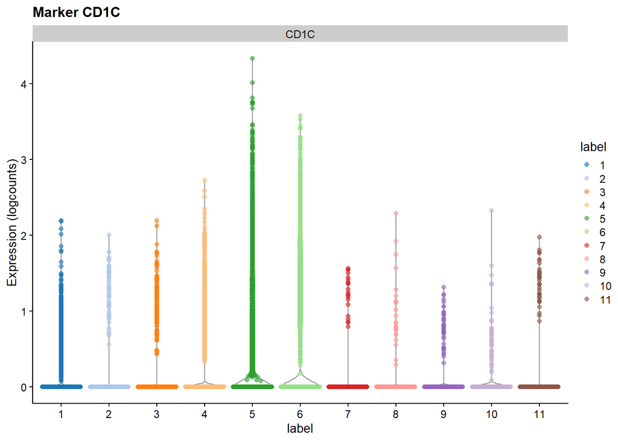

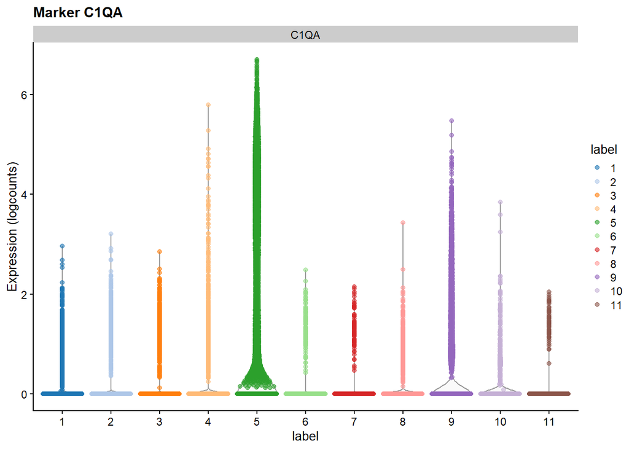

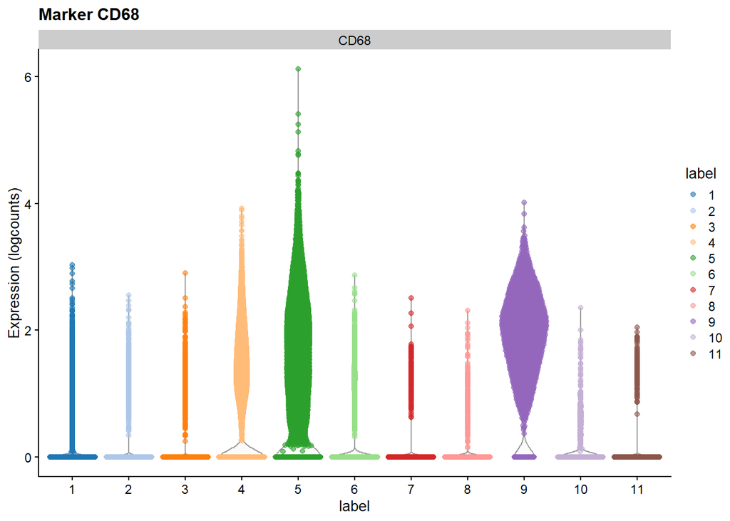

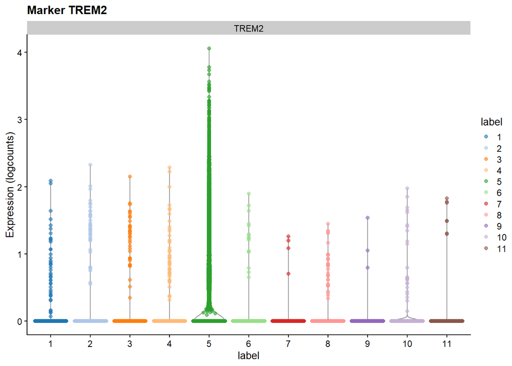

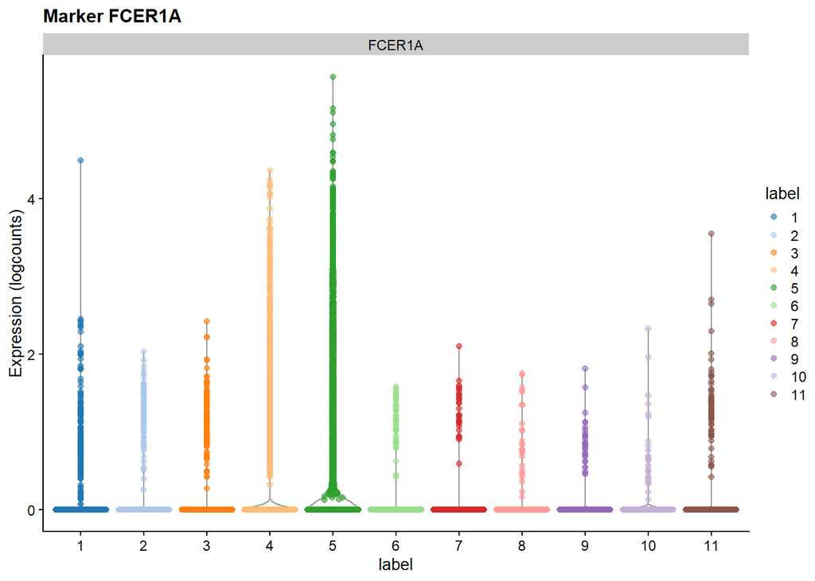

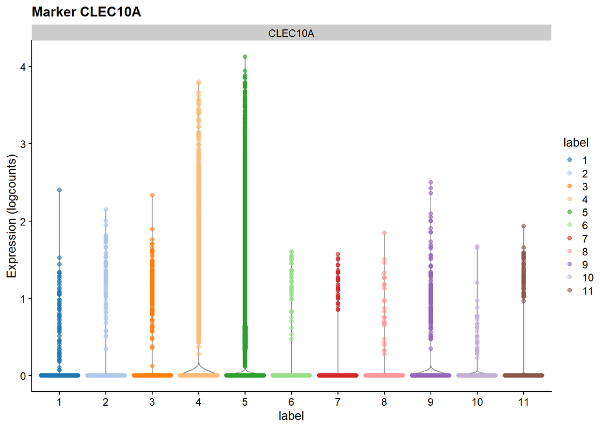

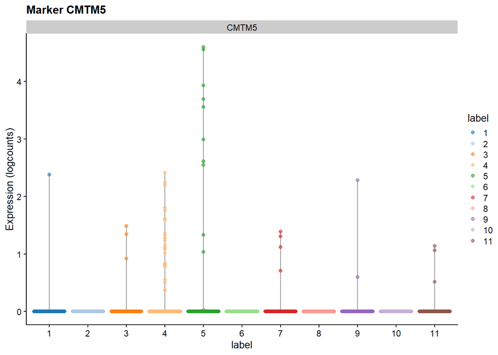

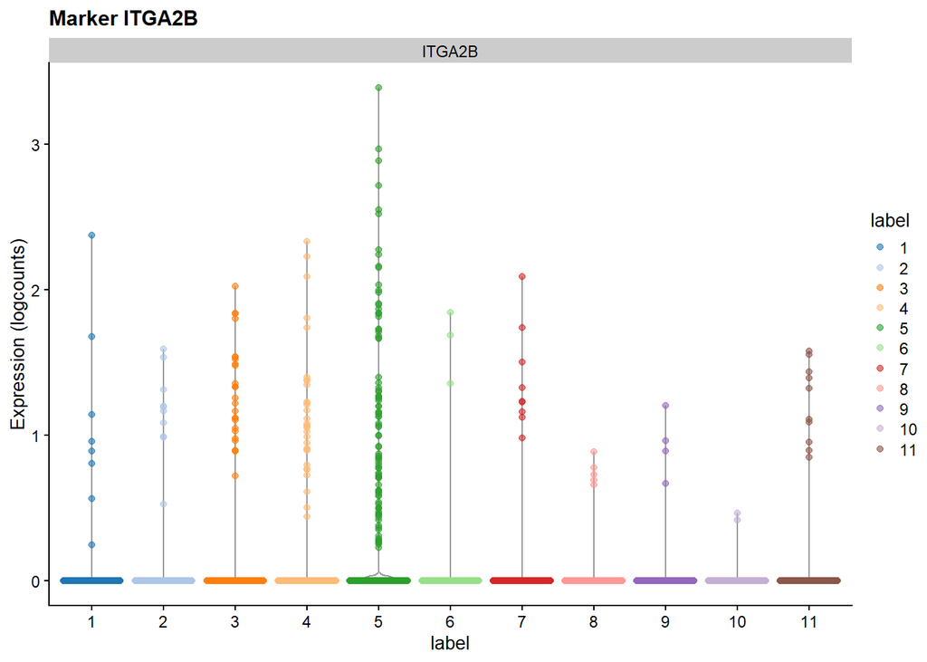

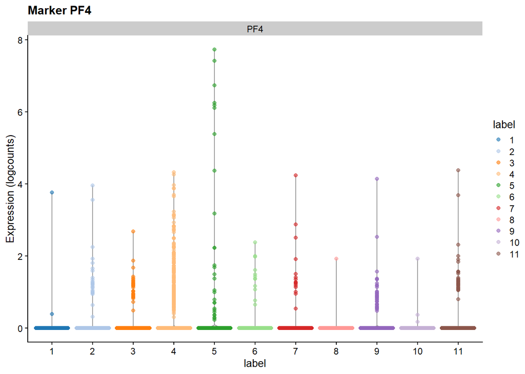

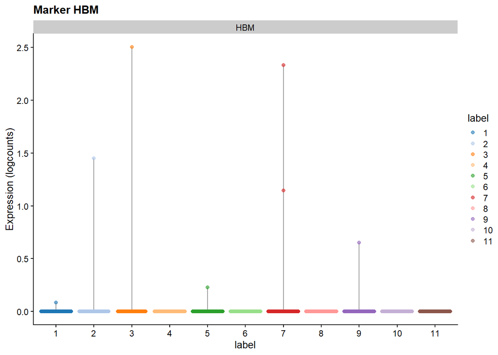

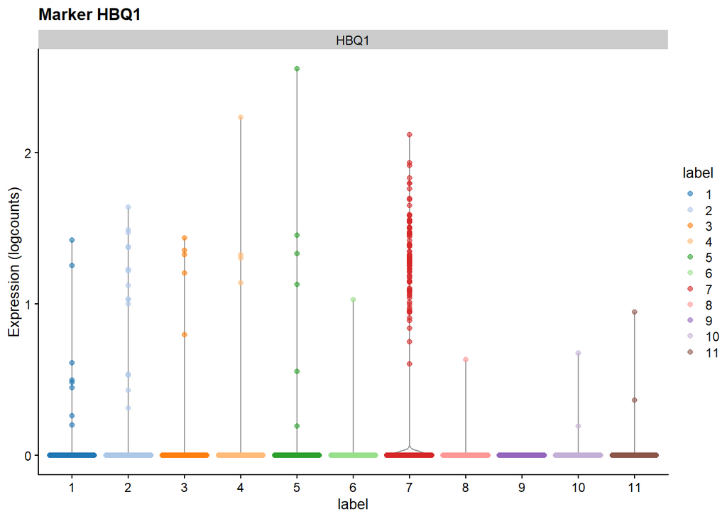

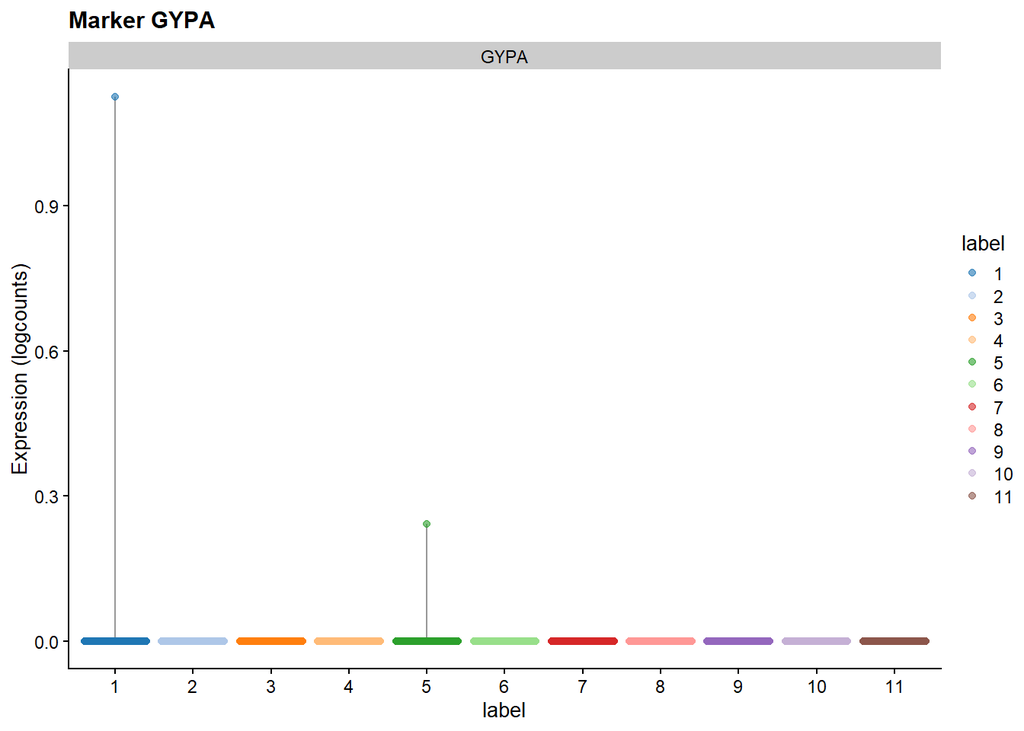

[4 more figures not shown]

```r
set.seed(100)

# Initialize an empty list to store the plots
plotList2 <- list()

curated_markers = c('CD1C','C1QA','CD68','TREM2','FCER1A','CLEC10A', 'CMTM5', 'ITGA2B', 'PF4', 'HBM', 'HBQ1', 'GYPA', 'S100A9', 'LYZ', 'MPO', 'SERPINB1')

# Loop through each cluster
for(i in seq_along(curated_markers)) {
  # Generate the plot for the current cluster
  p <- plotExpression(sce.all, features=curated_markers[i],
                      x="label", colour_by="label") +
    ggtitle(paste0("Marker ", curated_markers[i]))

  # Add the plot to the list
  plotList2[[i]] <- p
}

plotList2
```

```r
#library(gridExtra)
#x11()

# Arrange the plots in a grid
#grid.arrange(grobs = plotList2, nrow = 8, ncol = 2)
```

plot heatmap to identify clusters with myeloid cells(curated markers)

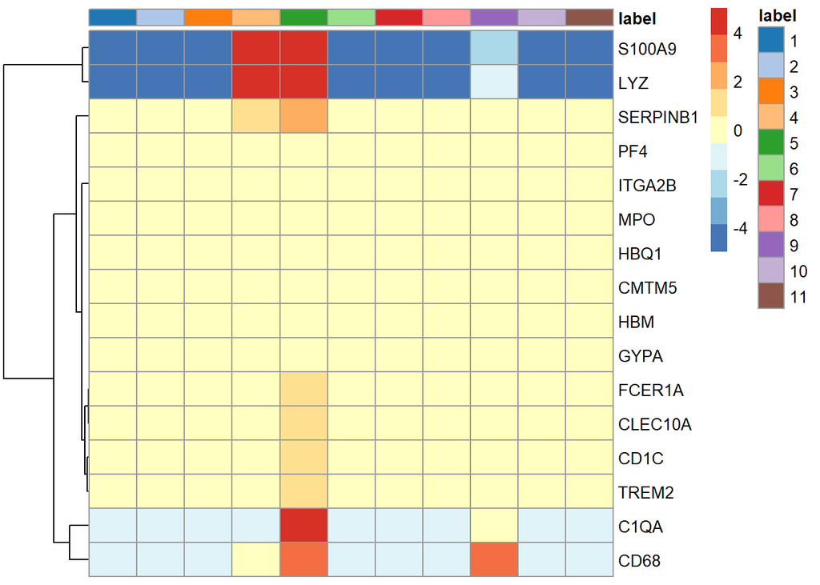

```r
#Remove repreated column names by making the colnames a sequence of numbers
colnames(sce.all) <- as.character(seq(1, 126630))

# Compute mean expression per cluster
avg_data <- aggregateAcrossCells(sce.all, ids = sce.all$label, statistics = "mean",use.assay.type = "counts")

# Now plot the heatmap
plotHeatmap(avg_data, features=curated_markers,exprs_values = "counts", order_columns_by="label",
            colour_columns_by="label",
            center=TRUE, symmetric=TRUE, zlim=c(-5, 5))
```

```r
#R documentation (scuttle package)
```

Cell Type Classification using a Reference dataset

```r
set.seed(100)

# Aggregate the count data across cells for each identified cluster label in the 'sce.all' object
sce.aggregated <- sumCountsAcrossCells(sce.all, id=colLabels(sce.all))

# Load the Human Primary Cell Atlas data, which will be used as a reference dataset for cell type annotation
hpc <- HumanPrimaryCellAtlasData()
```

```
## see ?celldex and browseVignettes('celldex') for documentation
```

```
## loading from cache
```

```
## see ?celldex and browseVignettes('celldex') for documentation
```

```
## loading from cache
```

```r
# Perform cell type annotation using the 'SingleR' function
anno.sce <- SingleR(sce.aggregated, ref = hpc, labels = hpc$label.main,
    assay.type.test="sum")

anno.sce
```

```
## DataFrame with 11 rows and 4 columns
##                            scores      labels delta.next pruned.labels
##                          <matrix> <character>  <numeric>   <character>
## 1  0.337959:0.739506:0.661768:...     T_cells  0.1218393            NA
## 2  0.309901:0.672428:0.631508:...     T_cells  0.2037404       T_cells
## 3  0.317410:0.688547:0.633986:...     T_cells  0.1721115       T_cells
## 4  0.280975:0.624444:0.694156:...    Monocyte  0.3270841      Monocyte
## 5  0.289466:0.618232:0.656624:...    Monocyte  0.0206833      Monocyte
## 6  0.299467:0.787835:0.650540:...      B_cell  0.0507439        B_cell
## 7  0.311122:0.666987:0.639891:...     NK_cell  0.0701503       NK_cell
## 8  0.317131:0.672756:0.627994:...     T_cells  0.2293776       T_cells
## 9  0.284825:0.643156:0.673754:...    Monocyte  0.2842114      Monocyte
## 10 0.315651:0.739737:0.671216:...      B_cell  0.1266380        B_cell
## 11 0.310343:0.679382:0.639909:...     T_cells  0.2248915       T_cells
```

```r
#writexl::write_xlsX(data.frame(anno.sce), 'anno.sce.xlsx', rownames = TRUE)
```

##### 11. Deferrencial Expression Between Conditions

**11.1 DE Between HNSCC and Healthy Donor Cells**

Subset Data to retain only the myeloid cell clusters for DE analysis

```r
# Filter cells based on myeloid cells labels/clusters
sce.myeloid <- sce.all[, sce.all$label %in% c(4, 5, 9)]

#confirm labels in subset dataset
unique(sce.myeloid$label)
```

```
## [1] 5 4 9
## Levels: 1 2 3 4 5 6 7 8 9 10 11
```

```r
sce.myeloid
```

```
## class: SingleCellExperiment
## dim: 33694 26631
## metadata(65): merge.info pca.info ... Samples Samples
## assays(3): reconstructed counts logcounts
## rownames(33694): RP11-34P13.3 FAM138A ... AC213203.1 FAM231B
## rowData names(3): rotation ID Symbol
## colnames(26631): 3 4 ... 126623 126629
## colData names(13): batch Sample ... sizeFactor label
## reducedDimNames(2): corrected UMAP
## mainExpName: NULL
## altExpNames(0):
```

**11.1. Creating pseudo-bulk samples**

```r
# Create Using 'label' and 'sample' as our two factors; each column of the output
# corresponds to one unique combination of these two factors.
sce.summed <- aggregateAcrossCells(sce.myeloid,
    id=colData(sce.myeloid)[,c("label", "Sample")])
sce.summed
```

```
## class: SingleCellExperiment
## dim: 33694 176
## metadata(65): merge.info pca.info ... Samples Samples
## assays(1): counts
## rownames(33694): RP11-34P13.3 FAM138A ... AC213203.1 FAM231B
## rowData names(3): rotation ID Symbol
## colnames: NULL
## colData names(16): batch Sample ... Sample ncells
## reducedDimNames(2): corrected UMAP
## mainExpName: NULL
## altExpNames(0):
```

```r
# Removing all pseudo-bulk samples with 'insufficient' cells.
sce.summed <- sce.summed[,sce.summed$ncells >= 10]
```

**11.2 DE analysis for each of the labels**

Identify HNCC induced DE in each cell type (Monocytes)

```r
de.results <- pseudoBulkDGE(sce.summed,
    label=sce.summed$label,
    design=~condition,
    coef="conditionHNSCC",
    condition=sce.summed$condition
)

de.results
```

```
## List of length 3
## names(3): 4 5 9
```

**DE results for each label/Cluster**

Genes with positive log Fold Change (logFC) values are upregulated in the Head and Neck cancer (HNSCC) condition compared to the reference condition (HD), while genes with negative logFC values are downregulated.

The P-Value and False Discovery Rate (FDR) columns help gauge the statistical significance of these observations. Genes with low P-Value and FDR values are considered as strong candidates for being genuinely differentially expressed due to HNSCC.

Cluster 4 (Monocytes) Results

```r
cur.results4 <- de.results[['4']]


# Filter out rows with NA values in the relevant columns
non_na_genes <- cur.results4[!is.na(cur.results4$PValue) &
                             !is.na(cur.results4$FDR) &
                             !is.na(cur.results4$logFC), ]

# Filter genes based on the given criteria
filtered_genes <- non_na_genes[(non_na_genes$PValue < 0.05) &
                               (non_na_genes$FDR < 0.35) &
                               (abs(non_na_genes$logFC) > 1), ]

# Order the filtered genes by FDR and select the top 10 Genes
top_genes4 <- head(filtered_genes[order(filtered_genes$FDR), ], 10)
top_genes4<-data.frame(top_genes4)
top_genes4
```

```
##             logFC   logCPM        F       PValue        FDR
## RHBDD2   1.254217 4.775099 26.01106 3.212876e-06 0.02450460
## FLVCR2   1.551134 3.912362 21.47272 1.797760e-05 0.06855757
## IL1RAP   1.323005 4.547724 11.82757 1.106107e-03 0.34612244
## AREG     3.329398 7.051062 12.38784 9.047276e-04 0.34612244
## PIM1     1.343900 6.004011 11.99985 1.056085e-03 0.34612244
## SLC25A37 1.004383 6.662893 13.28628 5.809166e-04 0.34612244
## ARID5B   1.890541 3.690249 14.15157 4.001357e-04 0.34612244
## SLC2A3   1.089627 8.045580 12.40126 8.811969e-04 0.34612244
## THBS1    3.319028 7.434496 12.76509 7.691111e-04 0.34612244
## SOCS3    2.069222 8.111501 11.86631 1.134530e-03 0.34612244
```

Visualisation

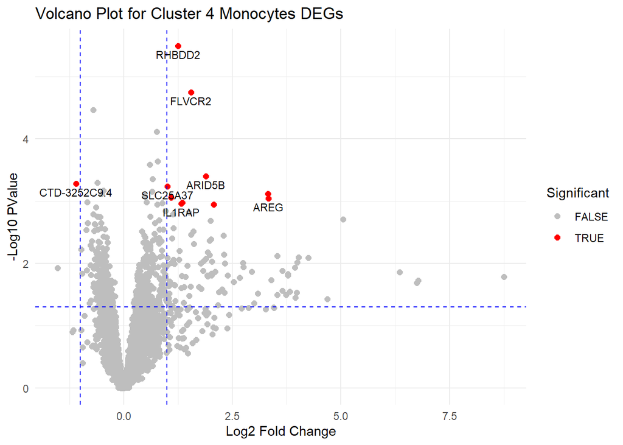

```r
# Create a new variable indicating which genes to label
cur.results4$label_genes <- with(cur.results4, ifelse(FDR < 0.35 & abs(logFC) > 1 & PValue < 0.05, rownames(cur.results4), NA))  # Assuming "GeneName" is the column with gene names

# Creating the volcano plot
volcano_plot <- ggplot(data.frame(cur.results4), aes(x = logFC, y = -log10(PValue))) +
  geom_point(aes(color = (FDR < 0.35 & abs(logFC) > 1&cur.results4$PValue < 0.05
)), size = 2) + # Adjust color condition for points based on significance and fold change threshold.
  scale_color_manual(values = c("TRUE" = "red", "FALSE" = "grey")) +
  labs(title = "Volcano Plot for Cluster 4 Monocytes DEGs",
       x = "Log2 Fold Change",
       y = "-Log10 PValue",
       color = "Significant") +
  theme_minimal() +
  geom_hline(yintercept = -log10(0.05), linetype = "dashed", color = "blue") + # p-value threshold line
  geom_vline(xintercept = 1, linetype = "dashed", color = "blue") +
  geom_vline(xintercept = -1, linetype = "dashed", color = "blue")+
  geom_text(aes(label = label_genes), vjust = 1.5, hjust = 0.5, size = 3, check_overlap = TRUE)# Adding gene names

# Display the plot
print(volcano_plot)
```

```r
#Source: https://biostatsquid.com/volcano-plots-r-tutorial/
```

Diagnostic plots to check for potential problems in the analysis

Model the mean-variance trend

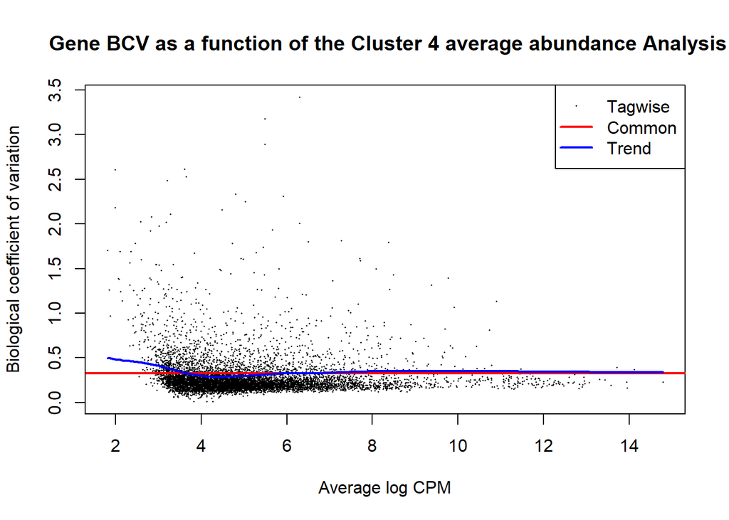

```r
#Diagnostic plots

cluster4_plot <- metadata(cur.results4)$y
plotBCV(cluster4_plot,main = ' Gene BCV as a function of the Cluster 4 average abundance Analysis')
```

**Cluster 5 (Monocytes) Results**

```r
cur.results5 <- de.results[['5']]

# select the top genes based on PValue FDR and LogFC

# Filter out rows with NA values in the relevant columns
non_na_genes5 <- cur.results5[!is.na(cur.results5$PValue) &
                             !is.na(cur.results5$FDR) &
                             !is.na(cur.results5$logFC), ]

# Filter genes based on the given criteria
filtered_genes5 <- non_na_genes5[(non_na_genes5$PValue < 0.05) &
                               (non_na_genes5$FDR < 0.1) &
                               (abs(non_na_genes5$logFC) > 1), ]

# Order the filtered genes by PValue and select the top 25
top_genes5 <- head(filtered_genes5[order(filtered_genes5$FDR), ], 10)
top_gene5<-data.frame(top_genes5)
data.frame(top_genes5)
```

```
##             logFC   logCPM        F       PValue          FDR
## LY6E     1.745769 8.283465 32.50431 3.975742e-07 0.0009238651
## WAC-AS1 -1.081416 4.808258 32.20349 4.231120e-07 0.0009238651
## MT2A     2.938985 8.972423 29.61935 1.102306e-06 0.0016045898
## IFI6     3.557330 7.934568 27.05245 2.727525e-06 0.0021969678
## EIF2AK2  1.339507 5.568705 27.53006 2.116350e-06 0.0021969678
## ISG15    3.119577 8.921095 22.34808 1.502274e-05 0.0059640298
## SLC11A1  4.125496 5.973802 23.37088 1.017782e-05 0.0059640298
## SHISA5   1.004254 5.577216 22.34212 1.416890e-05 0.0059640298
## PFKP     1.853345 4.947813 22.73764 1.220005e-05 0.0059640298
## ARID5B   2.416698 4.870859 21.51817 1.954074e-05 0.0065641860
```

Visualisation

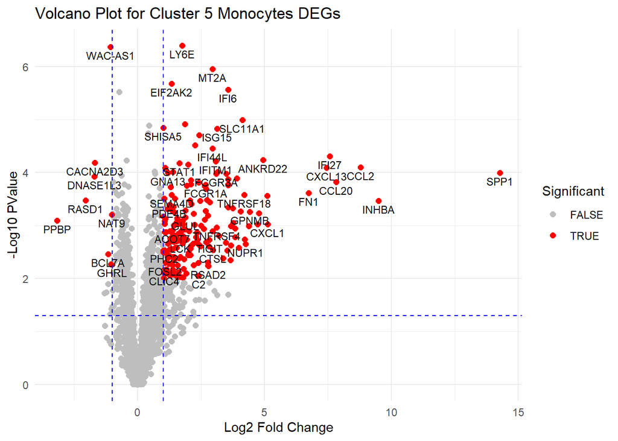

```r
# Create a new variable indicating which genes to label
cur.results5$label_genes <- with(cur.results5, ifelse(FDR < 0.1 & abs(logFC) > 1 & PValue < 0.05, rownames(cur.results5), NA))  # Assuming "GeneName" is the column with gene names

# Creating the volcano plot
volcano_plot <- ggplot(data.frame(cur.results5), aes(x = logFC, y = -log10(PValue))) +
  geom_point(aes(color = (FDR < 0.1 & abs(logFC) > 1)),
             size = 2) + # Adjust color condition for points based on significance and fold change threshold.
  scale_color_manual(values = c("TRUE" = "red", "FALSE" = "grey")) +
  labs(title = "Volcano Plot for Cluster 5 Monocytes DEGs",
       x = "Log2 Fold Change",
       y = "-Log10 PValue",
       color = "Significant") +
  theme_minimal() +
  geom_hline(yintercept = -log10(0.05), linetype = "dashed", color = "blue") + # p-value threshold line
  geom_vline(xintercept = 1, linetype = "dashed", color = "blue") +
  geom_vline(xintercept = -1, linetype = "dashed", color = "blue")+
  geom_text(aes(label = label_genes), vjust = 1.5, hjust = 0.5, size = 3, check_overlap = TRUE)# Adding gene names


# Display the plot
print(volcano_plot)
```

```r
#source: https://biostatsquid.com/volcano-plots-r-tutorial/
```

Diagnostic plots to check for potential problems in the analysis

Model the mean-variance trend

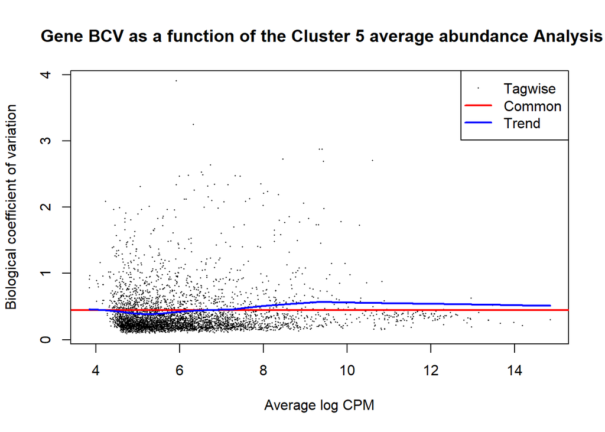

```r
#Diagnostic plots

cluster5_plot <- metadata(cur.results5)$y
plotBCV(cluster5_plot,main = ' Gene BCV as a function of the Cluster 5 average abundance Analysis')
```

**Cluster 9 (Monocytes) Results**

```r
cur.results9 <- de.results[['9']]
#Present results in table

# select the top genes based on PValue FDR and LogFC

# Filter out rows with NA values in the relevant columns
non_na_genes9 <- cur.results9[!is.na(cur.results9$PValue) &
                             !is.na(cur.results9$FDR) &
                             !is.na(cur.results9$logFC), ]


# Filter genes based on the given criteria
filtered_genes9 <- non_na_genes9[(non_na_genes9$PValue < 0.05) &
                               (non_na_genes9$FDR < 0.6) &
                               (abs(non_na_genes9$logFC) > 1), ]

# Order the filtered genes by PValue and select the top 25
top_genes9 <- head(filtered_genes9[order(filtered_genes9$FDR), ], 10)
data.frame(top_genes9)
```

```
##              logFC    logCPM         F       PValue       FDR
## GCHFR     1.524606  4.474705 16.251784 0.0001924565 0.3939309
## PGRMC1    1.040251  4.613431 12.823575 0.0007825128 0.4912015
## TNFSF12   1.117958  4.594358 10.591408 0.0020584490 0.4952006
## MEG3     -1.851483  5.931237 10.049956 0.0031496777 0.5080430
## MT2A      1.443651 10.191695  9.376552 0.0041936594 0.5139015
## SELL      1.043524  5.661343  8.424816 0.0059730580 0.5423960
## RHBDD2    1.051499  4.802027  8.424987 0.0055319051 0.5423960
## SIGLEC14  1.169926  4.433352  7.699158 0.0077888968 0.5710677
## ARL4A     1.233846  6.885754  7.376942 0.0101634082 0.5771367
## BEST1     1.426699  7.417265  7.724739 0.0086820164 0.5771367
```

Visualisation of Selected Genes

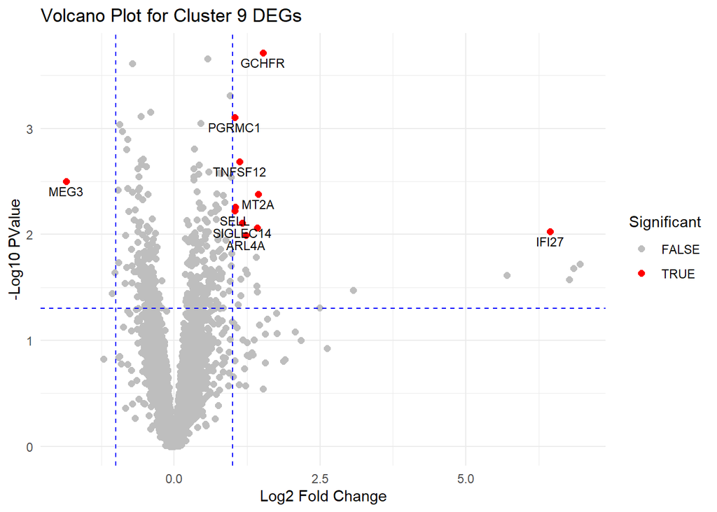

```r
# Create a new variable indicating which genes to label
cur.results9$label_genes <- with(cur.results9, ifelse(FDR < 0.6 & abs(logFC) > 1 & PValue < 0.05, rownames(cur.results9), NA))  # Assuming "GeneName" is the column with gene names

# Creating the volcano plot
volcano_plot <- ggplot(data.frame(cur.results9), aes(x = logFC, y = -log10(PValue))) +
  geom_point(aes(color = (FDR < 0.6 & abs(logFC) > 1)),
             size = 2) + # Adjust color condition for points based on significance and fold change threshold.
  scale_color_manual(values = c("TRUE" = "red", "FALSE" = "grey")) +
  labs(title = "Volcano Plot for Cluster 9 DEGs",
       x = "Log2 Fold Change",
       y = "-Log10 PValue",
       color = "Significant") +
  theme_minimal() +
  geom_hline(yintercept = -log10(0.05), linetype = "dashed", color = "blue") + # p-value threshold line
  geom_vline(xintercept = 1, linetype = "dashed", color = "blue") +
  geom_vline(xintercept = -1, linetype = "dashed", color = "blue")+
  geom_text(aes(label = label_genes), vjust = 1.5, hjust = 0.5, size = 3, check_overlap = TRUE)# Adding gene names


# Display the plot
print(volcano_plot)
```

```r
#Source: https://biostatsquid.com/volcano-plots-r-tutorial/
```

Diagnostic plots to check for potential problems in the analysis

Model the mean-variance trend

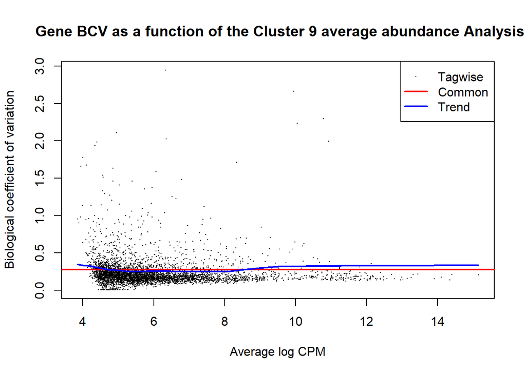

```r
#Diagnostic plots

cluster9_plot <- metadata(cur.results9)$y
plotBCV(cluster9_plot,main = ' Gene BCV as a function of the Cluster 9 average abundance Analysis')
```

check for labels that were skipped due to the absence of replicates or contrasts

```r
metadata(de.results)$failed
```

```
## character(0)
```

```r
# No skipped labels
```

Top 10 selected Marker genes associated with inflammation and Head and Neck Cancer in Myeloid cells (particularly monocytes)

```r
HNSCC_markers <-cbind(rownames(top_genes4),rownames(top_gene5),rownames(top_genes9))
colnames(HNSCC_markers) <- c('cluster4','cluster5','cluster9')
data.frame(HNSCC_markers)
```

```
##    cluster4 cluster5 cluster9
## 1    RHBDD2     LY6E    GCHFR
## 2    FLVCR2  WAC-AS1   PGRMC1
## 3    IL1RAP     MT2A  TNFSF12
## 4      AREG     IFI6     MEG3
## 5      PIM1  EIF2AK2     MT2A
## 6  SLC25A37    ISG15     SELL
## 7    ARID5B  SLC11A1   RHBDD2
## 8    SLC2A3   SHISA5 SIGLEC14
## 9     THBS1     PFKP    ARL4A
## 10    SOCS3   ARID5B    BEST1
```

**11.2 DE Between HNSCC and Healthy Donor PBMC cells**

DE between HNSCC and HD cells for PBMC cells

Subset for PBMC cells

```r
#sce.pbmc <- sce.myeloid[,colData(sce.myeloid)$celltype=='TRUE']
sce.pbmc <- sce.myeloid[, grepl("PBMC", colData(sce.myeloid)$Sample)]
sce.pbmc
```

```
## class: SingleCellExperiment
## dim: 33694 17624
## metadata(65): merge.info pca.info ... Samples Samples
## assays(3): reconstructed counts logcounts
## rownames(33694): RP11-34P13.3 FAM138A ... AC213203.1 FAM231B
## rowData names(3): rotation ID Symbol
## colnames(17624): 3 4 ... 114015 114017
## colData names(13): batch Sample ... sizeFactor label
## reducedDimNames(2): corrected UMAP
## mainExpName: NULL
## altExpNames(0):
```

**Creating pseudo-bulk samples**

```r
# Create Using 'label' and 'sample' as our two factors; each column of the output
# corresponds to one unique combination of these two factors.
sce.pbmc.summed <- aggregateAcrossCells(sce.pbmc,
    id=colData(sce.pbmc)[,c("label", "Sample")])
sce.pbmc.summed
```

```
## class: SingleCellExperiment
## dim: 33694 96
## metadata(65): merge.info pca.info ... Samples Samples
## assays(1): counts
## rownames(33694): RP11-34P13.3 FAM138A ... AC213203.1 FAM231B
## rowData names(3): rotation ID Symbol
## colnames: NULL
## colData names(16): batch Sample ... Sample ncells
## reducedDimNames(2): corrected UMAP
## mainExpName: NULL
## altExpNames(0):
```

```r
# Removing all pseudo-bulk samples with 'insufficient' cells.
sce..pbmc.summed <- sce.pbmc.summed[,sce.pbmc.summed$ncells >= 10]
```

PBMC DE analysis for each of the labels**

Identify HNCC induced DE in each cell type (Monocytes)

```r
pbmc.de.results <- pseudoBulkDGE(sce.pbmc.summed,
    label=sce.pbmc.summed$label,
    design=~condition,
    coef="conditionHNSCC",
    condition=sce.pbmc.summed$condition
)

pbmc.de.results
```

```
## List of length 3
## names(3): 4 5 9
```

Cluster 4 PBMC Results

```r
pbmc.cur.results4 <- pbmc.de.results[['4']]


# Filter out rows with NA values in the relevant columns
non_na_genes_pbmc4 <- pbmc.cur.results4[!is.na(pbmc.cur.results4$PValue) &
                             !is.na(pbmc.cur.results4$FDR) &
                             !is.na(pbmc.cur.results4$logFC), ]

# Filter genes based on the given criteria
filtered_genes_pbmc4 <- non_na_genes_pbmc4[(non_na_genes_pbmc4$PValue < 0.05) &
                               (non_na_genes_pbmc4$FDR < 0.35) &
                               (abs(non_na_genes_pbmc4$logFC) > 1), ]

# Order the filtered genes by FDR and select the top 10 Genes
pbmc_top_genes4 <- head(filtered_genes_pbmc4[order(filtered_genes_pbmc4$FDR), ], 10)
data.frame(pbmc_top_genes4)
```

```
##                   logFC   logCPM        F       PValue        FDR
## RHBDD2         1.089812 4.517792 34.39923 7.823213e-07 0.00655820
## FLVCR2         1.589723 3.811590 24.63201 1.390119e-05 0.05362946
## RP11-505K9.1   1.258054 2.793987 23.62722 1.919222e-05 0.05362946
## TNF           -2.170117 3.981263 22.95062 3.942589e-05 0.06610145
## ZEB2-AS1      -1.002957 3.866805 17.28367 1.693364e-04 0.13426347
## ADGRE3        -1.150974 2.759650 17.10213 1.809446e-04 0.13426347
## ARID5B         1.615251 3.313891 16.09029 2.690900e-04 0.14708204
## CTDSPL        -2.330230 2.956335 15.26534 4.713406e-04 0.20796045
## JUN           -1.346662 7.115679 14.39205 6.563742e-04 0.23923413
## CH17-373J23.1 -1.606136 7.431558 11.29017 2.119767e-03 0.27134972
```

Diagnostic plots to check for potential problems in the analysis

Model the mean-variance trend

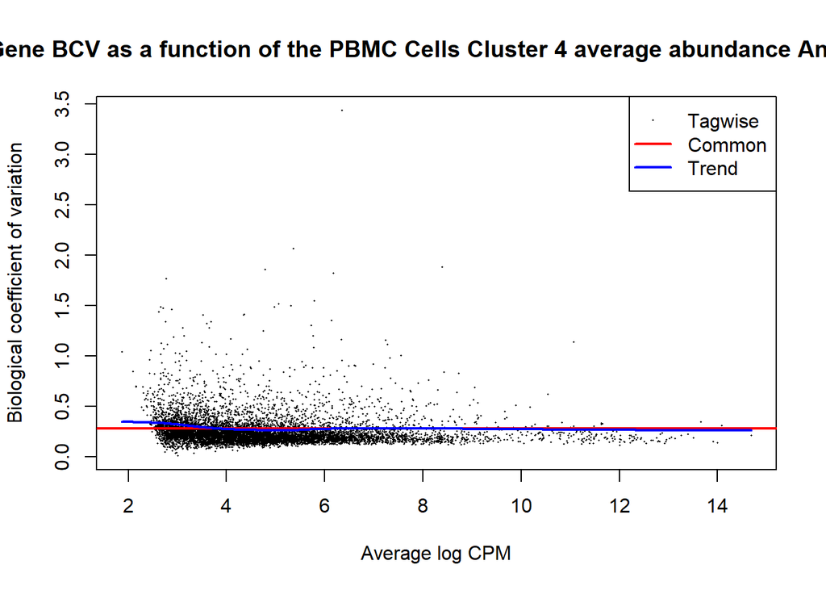

```r
#Diagnostic plots

pbmc_cluster4_plot <- metadata(pbmc.cur.results4)$y
plotBCV(pbmc_cluster4_plot,main = ' Gene BCV as a function of the PBMC Cells Cluster 4 average abundance Analysis')
```

Cluster 5 PBMC Results

```r
pbmc.cur.results5 <- pbmc.de.results[['5']]


# Filter out rows with NA values in the relevant columns
non_na_genes_pbmc5 <- pbmc.cur.results5[!is.na(pbmc.cur.results5$PValue) &
                             !is.na(pbmc.cur.results5$FDR) &
                             !is.na(pbmc.cur.results5$logFC), ]

# Filter genes based on the given criteria
filtered_genes_pbmc5 <- non_na_genes_pbmc5[(non_na_genes_pbmc5$PValue < 0.05) &
                               (non_na_genes_pbmc5$FDR < 0.9) &
                               (abs(non_na_genes_pbmc5$logFC) > 1), ]

# Order the filtered genes by FDR and select the top 10 Genes
pbmc_top_genes5 <- head(filtered_genes_pbmc5[order(filtered_genes_pbmc5$FDR), ], 10)
data.frame(pbmc_top_genes5)
```

```
##                  logFC   logCPM         F       PValue       FDR
## IL1B         -1.779553 5.828856 21.167935 5.701038e-05 0.1616814
## CACNA2D3     -1.027464 5.801502 16.811940 1.885169e-04 0.2673170
## CPNE3         1.075629 6.382031  9.782963 3.374063e-03 0.5036233
## CTD-3252C9.4 -1.309703 5.542786 11.590250 1.564037e-03 0.5036233
## BEST1         1.312481 6.248255  8.891894 5.243161e-03 0.6424989
## ISG20         1.154084 5.998785  8.984284 4.776608e-03 0.6424989
## ISG15         1.320137 7.217220  7.503570 1.015016e-02 0.7019578
## IFI6          1.728859 6.236396  6.998499 1.271125e-02 0.7019578
## PPBP         -3.089237 7.421889  8.191402 7.567674e-03 0.7019578
## VCAN          1.051343 6.524675  7.493366 9.739006e-03 0.7019578
```

Diagnostic plots to check for potential problems in the analysis

Model the mean-variance trend

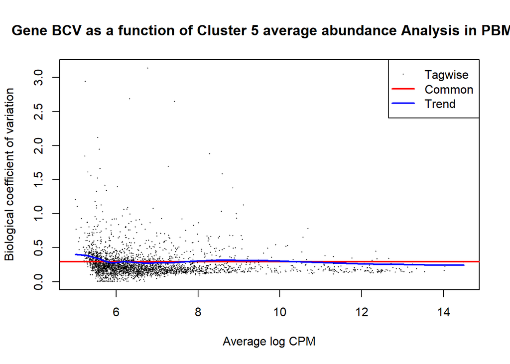

```r
#Diagnostic plots

pbmc_cluster5_plot <- metadata(pbmc.cur.results5)$y
plotBCV(pbmc_cluster5_plot,main = ' Gene BCV as a function of Cluster 5 average abundance Analysis in PBMCs')
```

Cluster 9 PBMC Results

```r
pbmc.cur.results9 <- pbmc.de.results[['9']]


# Filter out rows with NA values in the relevant columns
non_na_genes_pbmc9 <- pbmc.cur.results9[!is.na(pbmc.cur.results9$PValue) &
                             !is.na(pbmc.cur.results9$FDR) &
                             !is.na(pbmc.cur.results9$logFC), ]

# Filter genes based on the given criteria
filtered_genes_pbmc9 <- non_na_genes_pbmc9[(non_na_genes_pbmc9$PValue < 0.05) &
                               (non_na_genes_pbmc9$FDR < 0.6) &
                               (abs(non_na_genes_pbmc9$logFC) > 1), ]

# Order the filtered genes by FDR and select the top 10 Genes
pbmc_top_genes9 <- head(filtered_genes_pbmc9[order(filtered_genes_pbmc9$FDR), ], 10)
data.frame(pbmc_top_genes9)
```

```
##             logFC    logCPM         F       PValue       FDR
## GCHFR    1.463010  4.391871 16.511885 0.0001920837 0.2846398
## PGRMC1   1.063929  4.599299 14.634530 0.0004008803 0.3314320
## DLGAP4   1.033497  4.475240 13.487796 0.0006371139 0.3355760
## EIF2B4   1.242046  4.174319 12.532724 0.0009452646 0.3575700
## IL1B    -2.424096  4.919535 11.557165 0.0019108568 0.4644975
## BEST1    1.573721  7.525634 10.888706 0.0024819395 0.4644975
## MEG3    -1.896954  5.955753  9.733580 0.0039544617 0.4644975
## TNFSF12  1.105418  4.543688  9.653083 0.0032753440 0.4644975
## FAM35A   1.267823  4.172752  8.896789 0.0046074922 0.4676170
## MT2A     1.350625 10.093208  9.016349 0.0053252230 0.4774062
```

Diagnostic plot

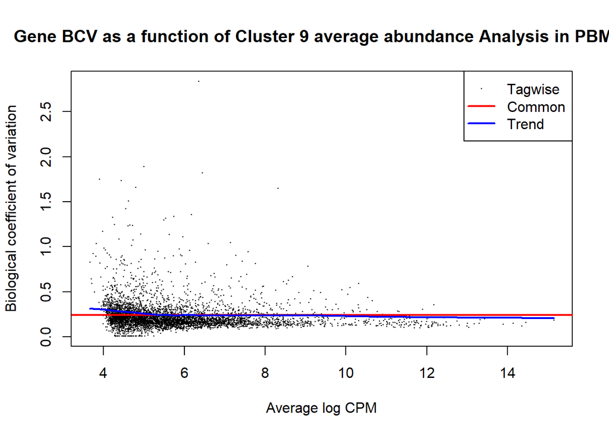

```r
#Diagnostic plots

pbmc_cluster9_plot <- metadata(pbmc.cur.results9)$y
plotBCV(pbmc_cluster9_plot,main = ' Gene BCV as a function of Cluster 9 average abundance Analysis in PBMCs')
```